Datos públicos reales · Superintendencia Financiera de Colombia vía datos.gov.co · informe generado automáticamente con R

DIANA RODRÍGUEZ← Todos los bancos

INFORME MENSUAL · NOVIEMBRE 2026

# Banco de Occidente: colocación de crédito

$1,82 billones

desembolsado en noviembre 2026

-67,0 %

frente a octubre 2026

7,1 %

del mercado · puesto 5 de 29

18,04 %

tasa ponderada E.A. (mercado 19,64 %)

## Lectura del mes

- En noviembre 2026, **Banco de Occidente** desembolsó **$1,82 billones** en 11.299 créditos, una caída de 67,0 % frente a octubre 2026.
- Tiene el **7,1 %** de lo desembolsado por los bancos y ocupa el puesto 5 de 29. Desde enero 2026 su participación ganó 0,13 puntos porcentuales.
- Su principal línea es **Comercial ordinario**, con el 72,2 % de su monto; ahí tiene el 11,0 % del mercado.
- En sus líneas principales cobra tasas cercanas al promedio del mercado (menos de 2 puntos de diferencia).

La tasa total depende de la mezcla de productos: un banco con más consumo tendrá una tasa promedio más alta. Por eso la comparación justa es por tipo de crédito, en la segunda gráfica.

## Participación en el mercado, mes a mes

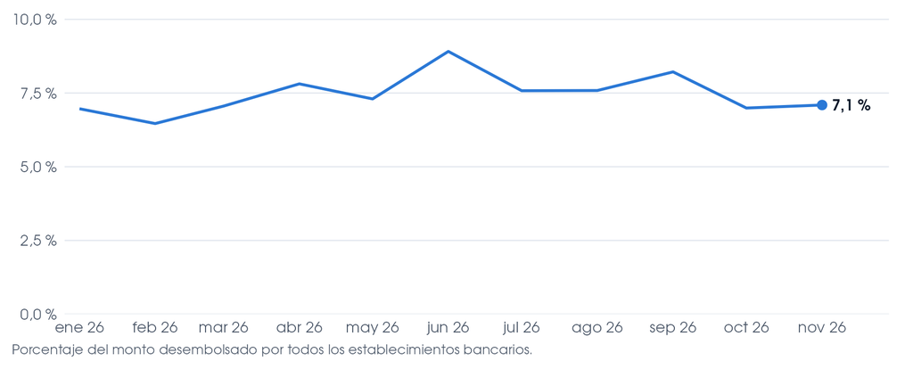

## Tasa por tipo de crédito: Banco de Occidente frente al mercado

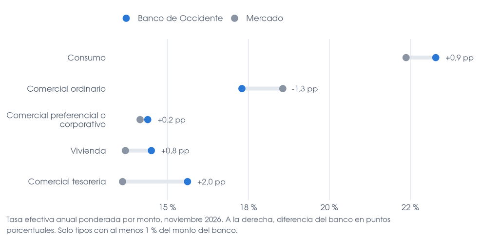

## En qué presta

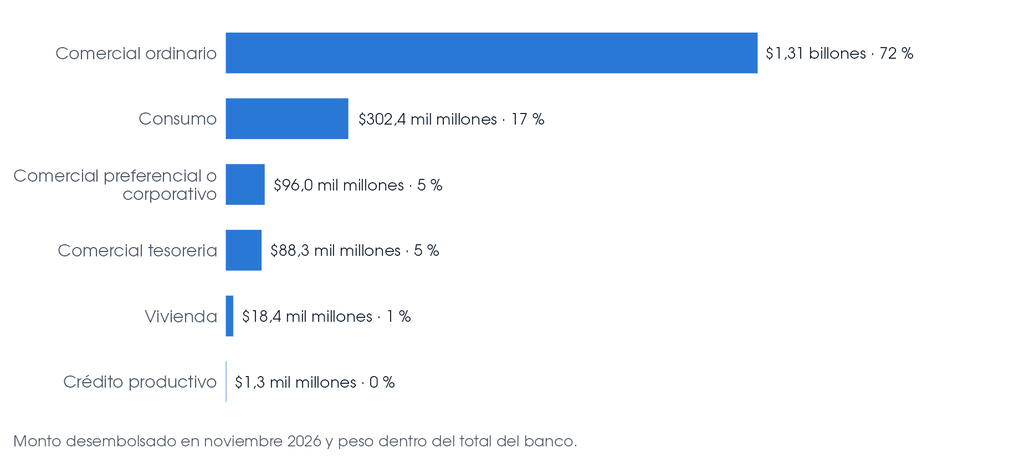

## Principales productos del mes

| Producto | Monto | Participación en el producto | Tasa banco | Tasa mercado | Diferencia |
| --- | --- | --- | --- | --- | --- |
| Oficial o gobierno | $359,3 mil millones | 77,7 % | 13,73 % | 13,81 % | -0,08 pp |
| Factoring | $279,9 mil millones | 12,4 % | 14,65 % | 14,62 % | +0,03 pp |
| Sobregiro en cuenta corriente persona jurídica o persona natural | $259,1 mil millones | 5,6 % | 28,19 % | 23,55 % | +4,64 pp |
| Comerciales con recursos provenientes de redescuento | $191,7 mil millones | 57,5 % | 13,36 % | 14,52 % | -1,16 pp |
| Tarjeta de crédito para ingresos superiores a 2 smmlv | $145,7 mil millones | 3,2 % | 26,27 % | 22,13 % | +4,15 pp |
| Empresarial en pesos | $98,2 mil millones | 3,4 % | 16,21 % | 16,32 % | -0,11 pp |
| Corporativo | $96,0 mil millones | 3,6 % | 14,40 % | 14,66 % | -0,26 pp |
| Empresarial - tesoreria | $88,3 mil millones | 20,0 % | 15,62 % | 13,61 % | +2,01 pp |

## Cómo se hizo

Este informe se escribe solo. Un script en R lee los datos que el Monitor de mercado descarga de la Superintendencia Financiera, calcula los indicadores y redacta el texto con reglas: por ejemplo, señala un tipo de crédito como «más caro que el mercado» cuando la diferencia supera 2 puntos y pesa al menos el 5 % del banco. Con R Markdown se genera un informe por cada banco, con los mismos parámetros. GitHub Actions lo vuelve a producir cada vez que llegan datos nuevos.

Montos en pesos corrientes. Tasas efectivas anuales ponderadas por el monto desembolsado. Cifras de enero 2026 a noviembre 2026; el último mes puede ajustarse cuando la Superintendencia publique correcciones. [Ver el código en GitHub →](https://github.com/dsrodriguezq/dsrodriguezq.github.io/tree/main/proyectos/informe-bancos-r)